# A spatiotemporal analysis of dengue in Brazil

By 02360909

31/03/2023

### Abstract

Brazil is one of the countries that are mostly affected by Dengue fever. Therefore, this study aimed to understand the effect of temperature, moisture, and accessibility to piped water on the incidence of dengue in Brazil, and described the spatial and temporal pattern of dengue incidence in Brazil. Two hierarchical spatial temporal models with or without time-space interaction were fitted with incidence rate of dengue as the response variable and temperature, moisture and accessibility to piped water as independent variables. It turned out there was a significant spatial pattern and temporal pattern of incidence rate of dengue in Brazil. Additionally, higher temperature can increase the incidence rate, while higher moisture reduce the rate. Better accessibility to piped water doesn’t show significant influence on the incidence of dengue.

### Introduction

Dengue fever is one of the most important emerging tropical diseases since last century, and Brazil is the country where the incidence of dengue is highest in the world. The number of cases in Brazil has once accounted for up to 60% of the dengue cases reported worldwide(Fares et al. 2015).

Dengue fever is mainly transmitted through the bite of female Aedes mosquito infected with dengue virus serotypes. Previous studies have proven that climate factors play an important role in the transmission of dengue by affecting mosquito growth dynamics, virus replication, and mosquito-human interaction(Zhang, Bi, and Hiller 2008). There were also some studies finding that lack of tap water can be a contributor to dengue fever outbreaks(Schmidt et al. 2011). In addition, the distribution of dengue cases is uneven in Brazil where the southeast region is the one mostly affected by dengue.Seasonality was also found to be related to the incidence of dengue by some studies(Andrioli, Busato, and Lutinski 2020).

Therefore, our study aimed to investigate the effect of accessibility to piped water and climate factors(temperature and moisture) on dengue risk, and look into the spatial and temporal pattern of dengue incidence in Brazil.

### Methods

#### Study site and data sources

557 Brazilian micro-regions are used as the spatial unit of analysis. The micro-regions are based on a geographical structure provided by the Brazilian Institute of Geography and Statistics. The island FERNANDO DE NORONHA with micro-region code 26019 was excluded for missing of covariates.

Population and monthly dengue cases in 557 micro-regions are obtained from the Notifiable Diseases Information System. Three covariates are included: Self-calbrated Palmer’s drought severity index (PDSI), Monthly minimum temperature(tmin), and the percentage of inhabitants with access to piped water network(water_network). PDSI is a drought index as a measurement of how wet or dry each micro-region is. Negative value stands for periods of drought, while positive values represents wet periods. PDSI was accessed from the Climatic Research Unit. According to the classification of drought severity with PDSI, we encoded PDSI into 7 levels: extreme drought(PDSI≤-4), severe drought(-4<PDSI≤-3), moderate drought(-3<PDSI≤-2), normal(-2<PDSI≤2), unusual moist(2<PDSI≤3), very moist(3<PDSI≤4), and extremely moist(4<PDSI).Data about minimum temperature is accessible from the website (https://www.uea.ac.uk/groups-and-centres/climatic-research-unit). Data of water_network are obtained from the census 2010.

#### Model specification

A spatiotemporal model is defined where the response variable is the incidence rate of dengue in 557 Brazilian micro-regions while tmin, PDSI, water_network, temporal effect and spatial effect are the independent variables. The incidence rate of dengue is assumed to comply with a Poisson distribution. In consideration of space-time interaction, two spatiotemporal models with and without space-time interaction are fitted respectively. All parameters are estimated using intergrated nested laplace approximations under the Bayesian framework. Statistical analysis is done in R version 4.2.2.

Model 1: Spatiotemporal model(no interaction)
$$\begin{eqnarray}
Incidence\ rate_{it} &\sim & \text{Poisson}(\rho_{it}) \\
\log \rho_{it} &= & b_0 + t_{min} + pdsi + waternetwork + b_i +
\gamma_t + \psi_t \\
\boldsymbol{b} &= &
\frac{1}{\sqrt{\tau_b}}(\sqrt{1-\phi}\boldsymbol{v}_{*} +
\sqrt{\phi}\boldsymbol{u}_{*})\\
\gamma_t & \sim & \hbox{RW(1)}\\
\psi_t & \sim & N(0,\sigma^2_{\psi})\\
\end{eqnarray}$$

$\boldsymbol{v}_{*}$ and $\boldsymbol{u}_{*}$ are standardised versions of $\boldsymbol{u}$ and $\boldsymbol{v}$. In detail, we specify the spatial random effect $\boldsymbol{b}$ using a re-parameterisation of the Besag-York-Molli'e prior, which is a convolution of an intrinsic conditional autoregressive (CAR) model and an independent and identically distributed Gaussian model, where

- $u_i$ is the spatially structured component defined by an intrinsic CAR prior: $\boldsymbol{u}\sim ICAR(\boldsymbol{W}, \sigma^2_u)$,
- $v_i$ the unstructured component defined with prior: $v_s \overset{iid}{\sim} \text{Normal}(0,\sigma^2_v)$.

Model 2: Spatiotemporal model(type I interaction)
$$\begin{eqnarray}
Incidence\ rate_{it} &\sim & \text{Poisson}(\rho_{it}) \\
\log \rho_{it} &= & b_0 + t_{min} + pdsi + waternetwork + b_i +
\gamma_t + \psi_t + \delta_{it} \\
\boldsymbol{b} &= &
\frac{1}{\sqrt{\tau_b}}(\sqrt{1-\phi}\boldsymbol{v}_{*} +
\sqrt{\phi}\boldsymbol{u}_{*})\\
\gamma_t & \sim & \hbox{RW(1)}\\
\psi_t & \sim & N(0,\sigma^2_{\psi})\\
\delta_{it} & \sim & \hbox{Normal}(0, \sigma^2_{\delta})
\end{eqnarray}$$

### Results

#### Descriptive analysis

As is showed in figure 1, there was a seasonal pattern of the incidence rate of dengue, where the rate of dengue was higher from December to May, and went down in the latter half of the year. Additionally, a spatial pattern exists where the incidence rate is at higher level in the central west and south east of Brazil(Figure 2).

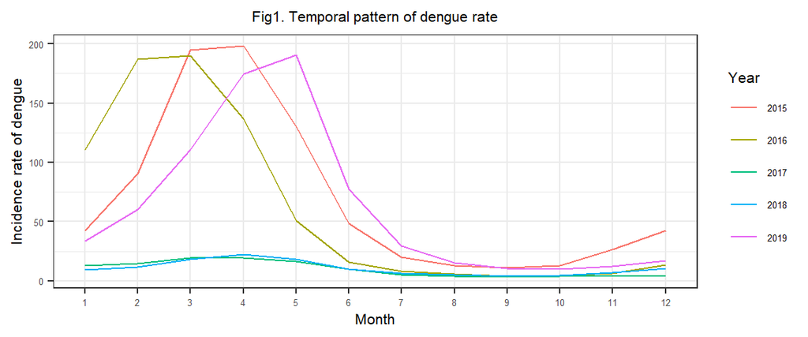

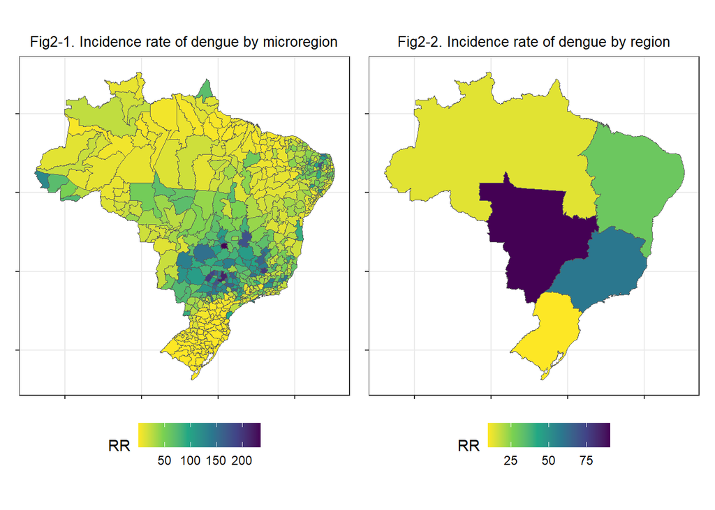

#### Fixed effects

In respective of fixed effects of Monthly minimum temperature(tmin), Drought severity index (PDSI), and access to water network, the results are consistent between two spatiotemporal models with or without interaction. Higher temperature is related to increased rate of dengue(No interaction: RR(95% CI)=1.11(1.11, 1.11); Type I interaction: RR(95% CI)=1.14(1.13, 1.16)). Overall speaking, moist climate lowers the incidence rate of dengue(table1), while extreme drought also decreases the incidence rate of dengue(No interaction: RR(95% CI)=0.90(0.89, 0.90); Type I interaction: RR(95% CI)=0.96(0.89, 1.04)). Accessibility to piped water shows very weak association with higher incidence rate(No interaction: RR(95% CI)=1.01(1.00, 1.01); Type I interaction: RR(95% CI)=1.02(1.01, 1.02)).

Table1. Rate ratio of fixed effects

|  | RR(95% CI)(No interaction) | RR(95% CI)(Type I interaction) |
| --- | --- | --- |
| Intercept | 0.56 (0.38, 0.83) | 0.1 (0.06, 0.16) |
| tmin | 1.11 (1.11, 1.11) | 1.14 (1.13, 1.16) |
| pdsi: Moderate drought vs normal | 1.36 (1.36, 1.37) | 1.21 (1.15, 1.27) |
| pdsi: Several drought vs normal | 1.12 (1.12, 1.13) | 1.11 (1.05, 1.18) |
| pdsi: Extreme drought vs normal | 0.9 (0.89, 0.9) | 0.96 (0.89, 1.04) |
| pdsi: Unusual moist vs normal | 0.49 (0.49, 0.5) | 0.9 (0.82, 0.98) |
| pdsi: Very moist vs normal | 0.41 (0.4, 0.41) | 0.92 (0.83, 1.02) |
| pdsi: Extremely moist vs normal | 0.85 (0.84, 0.86) | 1.02 (0.91, 1.16) |
| water network (no interaction) | 1.01 (1, 1.01) | 1.02 (1.01, 1.02) |

#### Spatiotemporal pattern

Adjusted for spatial pattern and other covariates(tmin, pdsi, and water_network), there is a clear seasonal pattern where incidence rate ratio of dengue went up from the December and went down from the middle of the year. In 2017 and 2018, incidence rate ratio of dengue was at an extremely low level. The temporal pattern is consistent whether fitting spatiotemporal interaction or not.

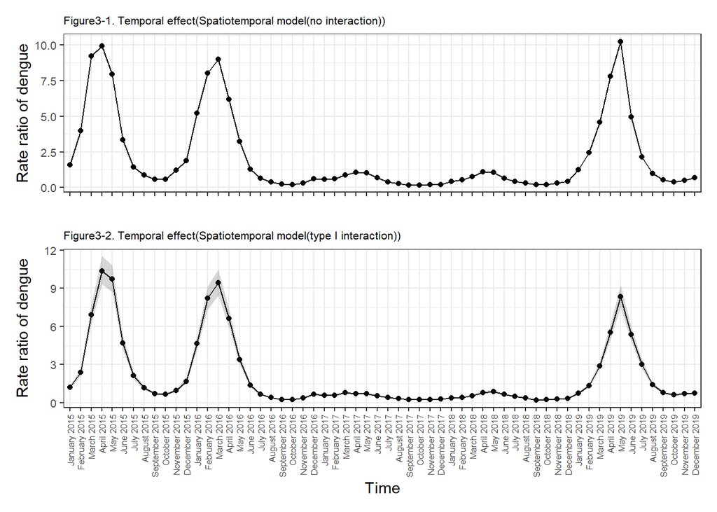

Adjusted for covariates and temporal effect, central west and south east of Brazil were the two regions with highest incidence rate ratio of dengue(Supplementary figure 4-1 and figure 4-2). By fitting a spatiotemporal model with type I interaction, the spatial effect was weakened. In addition, there is a marked spatiotemporal interaction as shown in Supplementary figure 5. The rate ratio in north west of Brazil went up drastically in 2019, and the incidence rate ratio in central west and south east went down since 2016, but went up again since 2018.

### Discussion and conclusion

#### Effects of temperature, drought, and accessibility to piped water

##### Temperature

Either in our spatial temporal model with or without interaction, temperature has a significant effect on dengue(No interaction: RR(95% CI)=1.11(1.11, 1.11); Type I interaction: RR(95% CI)=1.14(1.13, 1.16)). Higher temperature can promote the transmission of dengue while the lower temperature lowers the incidence rate of dengue.The impact of temperature is mainly realized by its influence on vectors. Lower temperature can slow down the development of vectors, generate smaller individuals,and decrease the capacity of attack(Simoy, Simoy, and Canziani 2015).

##### Drought

Our results shows that moderate and severe drought can increase the incidence rate of dengue, while moist condition and extreme drought bring down the risk. However, more studies claimed that both extremely wet condition and drought condition can increase the risk of dengue. A spatiotemporal study on dengue risk in Brazil revealed that the risk of dengue increased between 0-3 months after extremely wet conditions and 3-5 months after drought conditions(Lowe et al. 2021).In consideration of delayed and non-linear effects of extremely wet and extreme drought conditions, bias can be raised in our study. A time-lagged spatiotemporal model may explain the effect of PDSI better.

##### Accessibility to piped water

In our study, better access to piped water doesn’t reduce the risk of dengue, which is different from most other studies. It’s widely accepted that limited access to water supply might encourage mosquito breeding through use of water storage containers while piped water can slow down the transmission. However, in Brazil the effect of accessibility to piped water can be offset by increased population density. According to a study on dengue in Brazil, the proportion of residents living in urban areas is positively correlated with the proportion of residents with access to piped water network. Therefore, although improved access to piped water can decrease the risk of dengue, higher population density brought by higher proportion of the population residing in urban areas can increase the risk(Lowe et al. 2021).

#### Spatial and temporal pattern of dengue in Brazil

The incidence rate of dengue showed a marked seasonal pattern(Figure 3-1 and 3-2), where the rate went up from December and declined from May. This can be explained by the fact that the period from December to May is the rainy season as well as the hottest month of the year, which is in favor of the transmission of dengue(Fares et al. 2015).

In addition, Brazil experienced a drastic decrease in dengue in 2017 and 2018. Temporary or lasting cross-immunity generated by simultaneous circulation of several arboviruses may account for the phenomenon(Perez et al. 2019).Several studies suggested greater antibody responses to DENV and other arboviruses after ZIKV infection (Montoya et al. 2018).Another study claimed that the 2015 outbreak of Zika in Brazil might have inhibited transmission of DENV or symptomatic infection by inducing cross‐protective immunity against dengue virus(Ribeiro et al. 2018).Additionally, many other factors can play a role like changes in mosquito density and competence and increased vector control activities.(Perez et al. 2019).

Central west and south east are the two regions with highest incidence adjusted for covariates and temporal effect(Supplementary Figure 4-1 and 4-2 ). One reason may be the population density. For instance, the southeast region, composed of Rio de Janeiro and São Paulo is the region with the highest population density in Brazil(Andrioli, Busato, and Lutinski 2020). On the contrast, the southern part of Brazil enjoys the lowest incidence rate of dengue, which can be attributed to better urbanization and sanitation(Andrioli, Busato, and Lutinski 2020).

### Supplementary

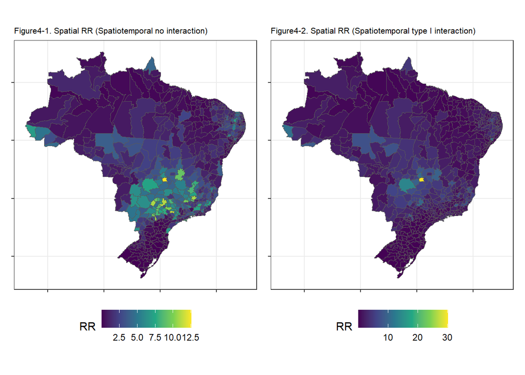

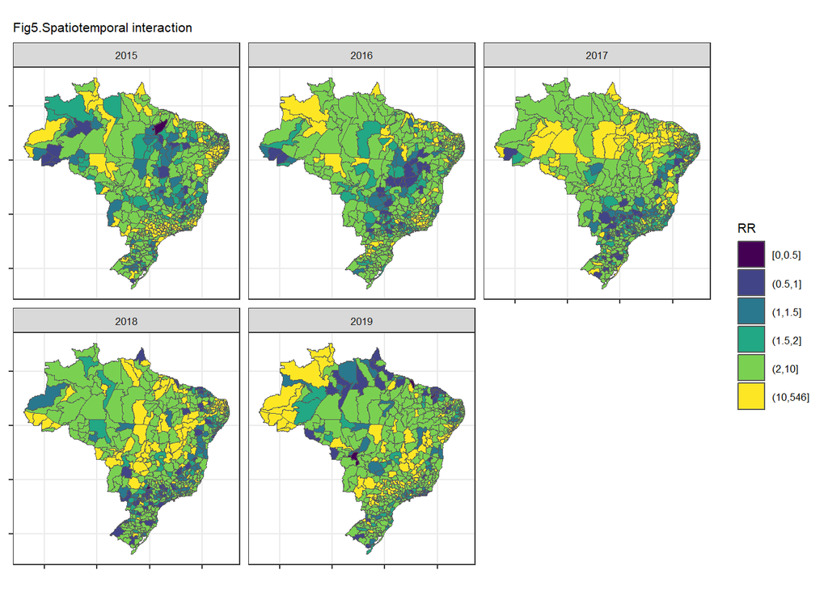

### References

Andrioli, Denise Catarina, Maria Assunta Busato, and Junir Antonio Lutinski. 2020. “Spatial and Temporal Distribution of Dengue in Brazil, 1990-2017.” *PLoS One* 15 (2): e0228346.

Fares, Rafaelle CG, Katia PR Souza, Germán Añez, and Maria Rios. 2015. “Epidemiological Scenario of Dengue in Brazil.” *BioMed Research International* 2015.

Lowe, Rachel, Sophie A Lee, Kathleen M O’Reilly, Oliver J Brady, Leonardo Bastos, Gabriel Carrasco-Escobar, Rafael de Castro Catão, et al. 2021. “Combined Effects of Hydrometeorological Hazards and Urbanisation on Dengue Risk in Brazil: A Spatiotemporal Modelling Study.” *The Lancet Planetary Health* 5 (4): e209–19.

Montoya, Magelda, Matthew Collins, Wanwisa Dejnirattisai, Leah C Katzelnick, Henry Puerta-Guardo, Ramesh Jadi, Samuel Schildhauer, et al. 2018. “Longitudinal Analysis of Antibody Cross-Neutralization Following Zika Virus and Dengue Virus Infection in Asia and the Americas.” *The Journal of Infectious Diseases* 218 (4): 536–45.

Perez, Freddy, Anthony Llau, Gamaliel Gutierrez, Haroldo Bezerra, Giovanini Coelho, Steven Ault, Sulamita Brandao Barbiratto, et al. 2019. “The Decline of Dengue in the Americas in 2017: Discussion of Multiple Hypotheses.” *Tropical Medicine & International Health* 24 (4): 442–53.

Ribeiro, Guilherme Sousa, Mariana Kikuti, Laura B Tauro, Leile Camila J Nascimento, Cristiane W Cardoso, Gúbio S Campos, Albert I Ko, et al. 2018. “Does Immunity After Zika Virus Infection Cross-Protect Against Dengue?” *The Lancet Global Health* 6 (2): e140–41.

Schmidt, W. P., M. Suzuki, V. D. Thiem, R. G. White, A. Tsuzuki, L. M. Yoshida, H. Yanai, et al. 2011. “Population Density, Water Supply, and the Risk of Dengue Fever in Vietnam: Cohort Study and Spatial Analysis.” Journal Article. *PLoS Med* 8 (8): e1001082. https://doi.org/10.1371/journal.pmed.1001082.

Simoy, Mario Ignacio, Maria Veronica Simoy, and Graciela Ana Canziani. 2015. “The Effect of Temperature on the Population Dynamics of Aedes Aegypti.” *Ecological Modelling* 314: 100–110.

Zhang, Ying, Peng Bi, and Janet E Hiller. 2008. “Climate Change and the Transmission of Vector-Borne Diseases: A Review.” *Asia Pacific Journal of Public Health* 20 (1): 64–76.